# Flights Dataset Exploration

## Preliminary Wrangling

This dataset contain reports of flights in the United States, including carriers, origins & destinations, arrival and departure delays along with the different reasons for delays, from 2006 to 2008

```python
# import all packages and set plots to be embedded inline
import numpy as np
import pandas as pd
import matplotlib.pyplot as plt
import seaborn as sb

%matplotlib inline
```

As the flights' reports for each year are in a separate file, we will load the files and combine them to do a year-by-year comparison.

```python
df2008 = pd.read_csv('2008.csv')
df2007 = pd.read_csv('2007.csv')
df2006 = pd.read_csv('2006.csv')
```

```python
#to allow showing all columns in .head()

pd.set_option('max_columns', None)
```

```python
#Let's check each of our files..

print(df2008.shape)
print(df2008.info())
```

```
(7009728, 29)
<class 'pandas.core.frame.DataFrame'>
RangeIndex: 7009728 entries, 0 to 7009727
Data columns (total 29 columns):
Year                 int64
Month                int64
DayofMonth           int64
DayOfWeek            int64
DepTime              float64
CRSDepTime           int64
ArrTime              float64
CRSArrTime           int64
UniqueCarrier        object
FlightNum            int64
TailNum              object
ActualElapsedTime    float64
CRSElapsedTime       float64
AirTime              float64
ArrDelay             float64
DepDelay             float64
Origin               object
Dest                 object
Distance             int64
TaxiIn               float64
TaxiOut              float64
Cancelled            int64
CancellationCode     object
Diverted             int64
CarrierDelay         float64
WeatherDelay         float64
NASDelay             float64
SecurityDelay        float64
LateAircraftDelay    float64
dtypes: float64(14), int64(10), object(5)
memory usage: 1.5+ GB
None
```

```python
print(df2007.shape)
print(df2007.info())
```

```
(7453215, 29)
<class 'pandas.core.frame.DataFrame'>
RangeIndex: 7453215 entries, 0 to 7453214
Data columns (total 29 columns):
Year                 int64
Month                int64
DayofMonth           int64
DayOfWeek            int64
DepTime              float64
CRSDepTime           int64
ArrTime              float64
CRSArrTime           int64
UniqueCarrier        object
FlightNum            int64
TailNum              object
ActualElapsedTime    float64
CRSElapsedTime       float64
AirTime              float64
ArrDelay             float64
DepDelay             float64
Origin               object
Dest                 object
Distance             int64
TaxiIn               int64
TaxiOut              int64
Cancelled            int64
CancellationCode     object
Diverted             int64
CarrierDelay         int64
WeatherDelay         int64
NASDelay             int64
SecurityDelay        int64
LateAircraftDelay    int64
dtypes: float64(7), int64(17), object(5)
memory usage: 1.6+ GB
None
```

```python
print(df2006.shape)
print(df2006.info())
```

```
(7141922, 29)
<class 'pandas.core.frame.DataFrame'>
RangeIndex: 7141922 entries, 0 to 7141921
Data columns (total 29 columns):
Year                 int64
Month                int64
DayofMonth           int64
DayOfWeek            int64
DepTime              float64
CRSDepTime           int64
ArrTime              float64
CRSArrTime           int64
UniqueCarrier        object
FlightNum            int64
TailNum              object
ActualElapsedTime    float64
CRSElapsedTime       float64
AirTime              float64
ArrDelay             float64
DepDelay             float64
Origin               object
Dest                 object
Distance             int64
TaxiIn               int64
TaxiOut              int64
Cancelled            int64
CancellationCode     object
Diverted             int64
CarrierDelay         int64
WeatherDelay         int64
NASDelay             int64
SecurityDelay        int64
LateAircraftDelay    int64
dtypes: float64(7), int64(17), object(5)
memory usage: 1.5+ GB
None
```

### What is the structure of your dataset?

> We can see that the report of each year contains more than 7 millions obervations with a 29 columns of variables describing a lot of details about flights, such as: flight's date, origin & destinantion, planned / actual time of departure / arrival, if any cancellation / delays are recorded along with the reason's of cancellation / delay and some other details.

### What is/are the main feature(s) of interest in your dataset?

In this report, I'm interested in exploring the carrier delay which is by definition: "A delay due to circumstances within the airline's control (e.g. maintenance or crew problems, aircraft cleaning, baggage loading, fueling, etc.)".

### What features in the dataset do you think will help support your investigation into your feature(s) of interest?

I expect that the CarrierDelay will be affected by few features like Year & Origin.

To start, we will combine the datasets of 2006,2007 & 2008 so we can check the changes over the years, and we will filter out the duplicates and irrelevant features to end up with a lighter dataset.

```python
frames = [df2008, df2007, df2006]
df_merged = pd.concat(frames)

df_merged.shape
```

```
(21604865, 29)
```

```python
#let's drop the duplicates from the dataset

df_merged.drop_duplicates(inplace=True)

df_merged.reset_index(drop=True, inplace=True)
```

```python
#now let's create a new copy of the dataset after dropping the unneeded features

df = df_merged.copy().drop(['UniqueCarrier','FlightNum','TailNum','TaxiIn', 'TaxiOut','Diverted','Distance','CRSArrTime','AirTime','DepDelay','CRSDepTime','DepTime','ArrTime','ActualElapsedTime',
                            'Month','DayOfWeek','DayofMonth','Dest','Cancelled','CancellationCode','CRSElapsedTime','WeatherDelay','NASDelay','SecurityDelay','LateAircraftDelay'], axis=1)

df.info()
```

```
<class 'pandas.core.frame.DataFrame'>
RangeIndex: 21604827 entries, 0 to 21604826
Data columns (total 4 columns):
Year            int64
ArrDelay        float64
Origin          object
CarrierDelay    float64
dtypes: float64(2), int64(1), object(1)
memory usage: 659.3+ MB
```

```python
#As we are studying delay reasons, let's drop the flights with no delays (i.e: where ArrDelay <= 0)

df.drop(df[df['ArrDelay']<=0].index, inplace=True)

df.reset_index(drop=True, inplace=True)

df.info()
```

```
<class 'pandas.core.frame.DataFrame'>
RangeIndex: 10101049 entries, 0 to 10101048
Data columns (total 4 columns):
Year            int64
ArrDelay        float64
Origin          object
CarrierDelay    float64
dtypes: float64(2), int64(1), object(1)
memory usage: 308.3+ MB
```

```python
#Now let's create a new dataframe where CarrierDelay>0 as we are focusing on the flights where there was a CarrierDelay reported

df_carrDelay = df[df['CarrierDelay'] > 0].reset_index()

df_carrDelay.info()
```

```
<class 'pandas.core.frame.DataFrame'>
RangeIndex: 2203884 entries, 0 to 2203883
Data columns (total 5 columns):
index           int64
Year            int64
ArrDelay        float64
Origin          object
CarrierDelay    float64
dtypes: float64(2), int64(2), object(1)
memory usage: 84.1+ MB
```

## Univariate Exploration

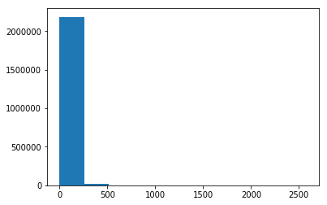

```python
#Let's have a look on the distibution of CarrierDeay variable

plt.hist(data = df_carrDelay, x='CarrierDelay');
```

The data looks extremely skewed..

Let's check the details of our variable:

```python
df_carrDelay['CarrierDelay'].describe()
```

```
count    2.203884e+06
mean     3.498895e+01
std      5.256141e+01
min      1.000000e+00
25%      9.000000e+00
50%      1.900000e+01
75%      4.000000e+01
max      2.580000e+03
Name: CarrierDelay, dtype: float64
```

As we can see, the median is 19 minutes & the mean is about 35 minutes but the maximum value is 2580 minutes!

There are clearly some outliers that we are better to remove

```python
#First let's extract the first & third quantiles of CarrierDelay and calculate our upper outlier boundary

q1, q3 = df_carrDelay.CarrierDelay.quantile([0.25,0.75])

upperLimit = q3+1.5*(q3-q1)
```

```python
#Reference: https://www.statisticshowto.com/statistics-basics/find-outliers/#:~:text=An%20outlier%20is%20defined%20as,3)in%20a%20data%20set.

#Now let's filter the outiers beyond our upper boundary (i.e: values above the range: Q3+1.5(Q3-Q1) )

df_carrDelay = df_carrDelay[df_carrDelay['CarrierDelay']<= upperLimit].reset_index()
```

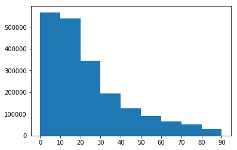

```python
#Now let's plot CarrierDelay again

bs = np.arange(0, df_carrDelay['CarrierDelay'].max()+10, 10)

plt.hist(data = df_carrDelay, x='CarrierDelay', bins = bs)


ticks = [0, 10, 20, 30, 40, 50, 60, 70, 80, 90]
labels = ['{}'.format(v) for v in ticks]

plt.xticks(ticks, labels);
```

The histogram is much better now but it is still right-skewed ..

Let's try appying a logarithmic transformation on our ditribution:

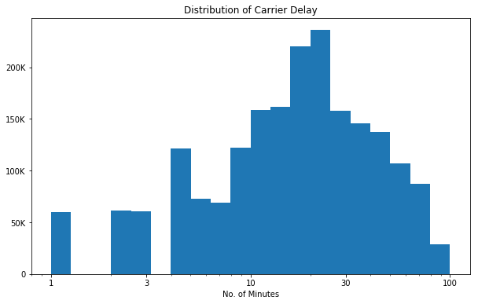

```python
plt.figure(figsize=(10,6))

bs = 10 ** np.arange(0, np.log10(df_carrDelay['CarrierDelay'].max())+0.1, 0.1)
plt.hist(data = df_carrDelay, x='CarrierDelay',bins=bs)
plt.xscale('log')

plt.title('Distribution of Carrier Delay')
plt.xlabel('No. of Minutes')

ticks = [1, 3, 10, 30, 100]
labels = ['{}'.format(v) for v in ticks]

plt.xticks(ticks, labels);
plt.yticks([0, 50000,100000,150000,200000],['0', '50K','100K','150K','200K']);
```

The logarithmic transformation gives us clearer details: We notice that there's a spike in frequency in carrier delays between 4 & 5 minutes, then the frequencies goes down between 5 & 9 minutes, and then up again with a peak at almost a 20 minutes of delay before frequencies start to decrease.

Now let's check the number of flights with carrier delay reports over the years:

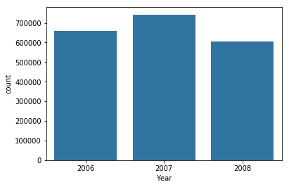

```python
base_color = sb.color_palette()[0]

sb.countplot(data=df_carrDelay, x='Year', color=base_color);
```

For the "Year" variable we picked only 2006,2007 & 2008. We notice that we have more flights with carrier delay reports in 2007.

Now let's have a look on the Origin variable:

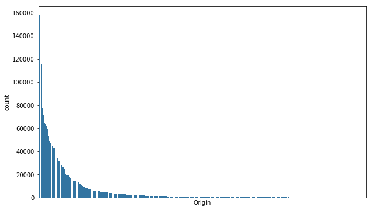

```python
plt.figure(figsize=(10,6))

type_order=df_carrDelay['Origin'].value_counts().index
sb.countplot(data=df_carrDelay, x='Origin', color=base_color, order=type_order);
plt.xticks([]);
```

There are clearly more frequent origins with reported CarrierDelays than others in the dataset. However, with such a load of origins, the individual names can't be fully displayed.

So let's plot the most common origins with CarrierDelays reports by picking those with 40,000 reports or more:

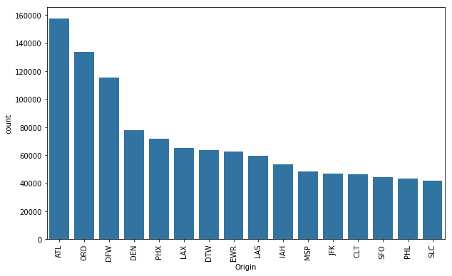

```python
plt.figure(figsize=(10,6))

df_origin_slice = df_carrDelay[df_carrDelay['Origin'].map(df_carrDelay['Origin'].value_counts()) >= 40000]

df_origin_slice.reset_index(drop=True)

type_order=df_origin_slice['Origin'].value_counts().index
sb.countplot(data=df_origin_slice, x='Origin', color=base_color, order=type_order);
plt.xticks(rotation=90);
```

We can see that the top 3 origins with over 100K CarrierDelays reports are: ATL - ORD - DFW

### Discuss the distribution(s) of your variable(s) of interest. Were there any unusual points? Did you need to perform any transformations?

The CarrierDelay variable took a large range of values, so I excluded the outliers and applied a logarithmic transformation afterwards.

The carrier delays looked multimodal, with a first spike in frequencies for carrier delays between 4 to 5 minutes, then a peak at 20 minutes of delay before the frequencies decrease.

### Of the features you investigated, were there any unusual distributions? Did you perform any operations on the data to tidy, adjust, or change the form of the data? If so, why did you do this?

I dropped the observations with no arrival delays and no carrier delays reports as I'm focusing on studing flights with carrier delay reports.

For the origin feature: There was a huge number of origins in the dataset which led to a totally unclear plot, so I focused on the most frequent ones with over 40,000 carrier delays reports.

## Bivariate Exploration

I'll start by looking at the changes of CarrierDelay over the years.

Let's compare our variables in a facetGrid:

```python
df_origin_slice.reset_index(drop=True);
```

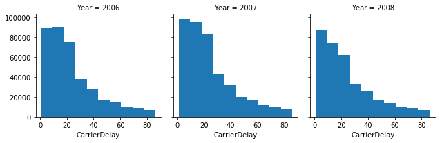

```python
# Plot the Seaborn's FacetGrid
#g = sb.FacetGrid(data = df_carrDelay, col = 'Year')
g = sb.FacetGrid(data = df_origin_slice, col = 'Year')

g.map(plt.hist, "CarrierDelay")
```

The plots look very similar over the years. However, since the distibutions have long right-tails, let's apply a logarithmic distribution and show the plots in layers:

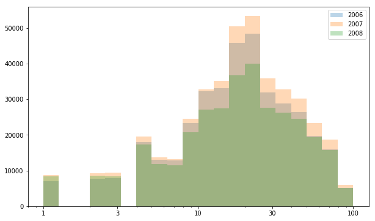

```python
plt.figure(figsize=(10,6))
bs = 10 ** np.arange(0, np.log10(df_origin_slice['CarrierDelay'].max())+0.1, 0.1)

plt.hist(data = df_origin_slice[df_origin_slice['Year']==2006], x='CarrierDelay', bins=bs, alpha=0.3, label='2006');
plt.hist(data = df_origin_slice[df_origin_slice['Year']==2007], x='CarrierDelay', bins=bs, alpha=0.3, label='2007');
plt.hist(data = df_origin_slice[df_origin_slice['Year']==2008], x='CarrierDelay', bins=bs, alpha=0.3, label='2008');
plt.legend()

plt.xscale('log')
ticks = [1, 3, 10, 30, 100]
labels = ['{}'.format(v) for v in ticks]
plt.xticks(ticks, labels);
```

So the histograms look almost idential over the years, with a litte higher frequencies in 2007.

Now let's look at the relashionship between CarrierDelay and Origin. Since CarrierDelay have a long range of values, I will aggregate the values by the median to avoid any bias towards outliers:

```python
#here I'll create a new column for the median of each origin-year combination then merge it with the dataframe
#Reference: https://stackoverflow.com/questions/35261838/pandas-calculate-median-of-group-over-columns


x = df_origin_slice.groupby(['Year','Origin'])['CarrierDelay'].median()

x.name ='CarrierDelayMedian'

df_origin_slice = df_origin_slice.join(x, on=['Year','Origin'])

df_origin_slice.reset_index(drop=True);
```

```python
df_origin_slice.head()
```

|  | level_0 | index | Year | ArrDelay | Origin | CarrierDelay | CarrierDelayMedian |
| --- | --- | --- | --- | --- | --- | --- | --- |
| 15 | 16 | 46 | 2008 | 43.0 | LAS | 15.0 | 14.0 |
| 16 | 17 | 47 | 2008 | 77.0 | LAS | 7.0 | 14.0 |
| 17 | 18 | 48 | 2008 | 50.0 | LAS | 50.0 | 14.0 |
| 18 | 19 | 50 | 2008 | 78.0 | LAS | 8.0 | 14.0 |
| 19 | 20 | 51 | 2008 | 38.0 | LAS | 3.0 | 14.0 |

Now let's plot CarrierDelay median by Origin:

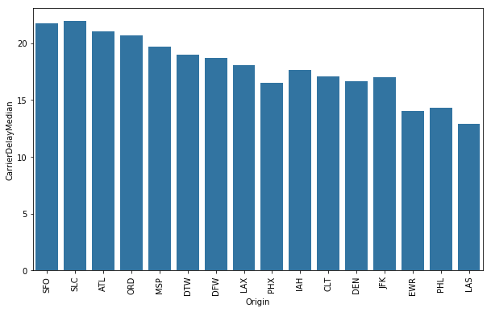

```python
df_origin_slice = df_origin_slice.sort_values(by='CarrierDelayMedian', ascending=False).reset_index(drop=True)

plt.figure(figsize=(10,6))


sb.barplot(data= df_origin_slice , x= 'Origin', y = 'CarrierDelayMedian', color=base_color, errwidth=0)

plt.xticks(rotation=90);
```

We notice that the Origins with the heighest median of CarrierDelays of more than 20 minutes are: SFO, SLC, ATL and ORD

We will examine this further by looking at the changes over the years later-on.

### Talk about some of the relationships you observed in this part of the investigation. How did the feature(s) of interest vary with other features in the dataset?

We didn't notice a very significant relashionship between CarrierDelay & Year, except for higher frequencies of CarrierDelays in 2007.

We also noticed that some origins have much higher median of CarrierDelays than others.

## Multivariate Exploration

> Earlier We looked at the CarrierDelay-Year and CarrierDelayMeidans-Origin relationships. Let's investigate this further by looking at the changes of CarrierDelay medians per Origin over the years.

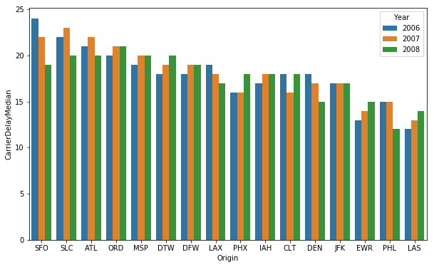

```python
plt.figure(figsize=(10,6))

sb.barplot(data=df_origin_slice, x='Origin', y='CarrierDelayMedian', hue='Year', ci=None);
```

We can see here that Origins with CarrierDelay medians differ across the years with few origins comming among those with the heighest medians over the years.

Let's focus on the top 6 origins with highest median of CarrierDelay and compare them across the years:

```python
High6_Origins = ['SFO','SLC','ATL','ORD', 'MSP', 'DTW']

df_origin_slice_high6=df_origin_slice[df_origin_slice['Origin'].isin(High6_Origins)].copy().reset_index(drop=True)
```

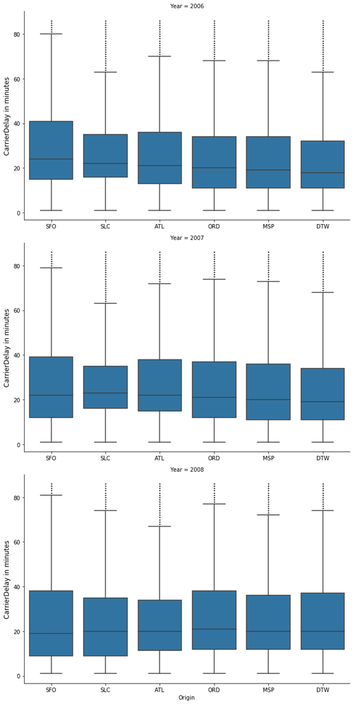

```python
g = sb.FacetGrid(data = df_origin_slice_high6, col = 'Year', height = 6, aspect=1.5,  col_wrap=1, sharex=False);
g.map(sb.boxplot, 'Origin', 'CarrierDelay', order=High6_Origins, fliersize=0.5);
g.add_legend();

for ax in g.axes.flat:
    ax.set_ylabel('CarrierDelay in minutes', fontsize='large')
```

We can see here that medians in this sub-group of origins are in the 20 minutes range, with some origins having more outliers than others like: SLC & DTW in 2006 & 2007, and ATL in 2008.

Let's take it further by highlighting the medians of this sub-group in each year:

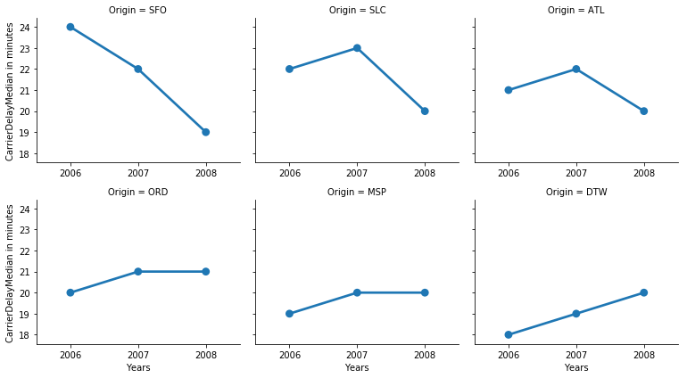

```python
g = sb.FacetGrid(data = df_origin_slice_high6, col = 'Origin', height = 3, aspect=1.2,  col_wrap=3, sharex=False, sharey=True);
g.map(sb.pointplot, 'Year', 'CarrierDelayMedian', order=[2006,2007,2008]);
g.set_axis_labels("Years", 'CarrierDelayMedian in minutes');
```

Now it's clear that for most of these origins, medians of CarrierDelay in 2008 are less or equal to 2007, except for DTW.

### Talk about some of the relationships you observed in this part of the investigation. Were there features that strengthened each other in terms of looking at your feature(s) of interest?

By extending our investigation to include Year & Origin variables, we were able to have a better understanding of the changes in our variable of interest (CarrierDelay) and its relationship to the Origin & Year.

We noticed that the order of origins with the hightest medians of CarrierDelays is changing from year to year, and it seems that our variables are not totally independent.

### Were there any interesting or surprising interactions between features?

Although that the order of the origins with highest medians of CarrierDelays is changing from year to year, but some origins, like: ORD, SLC & ATL, remain among the highest over the years. This is interesting and the reasons behind such delays worth further investigation.